# L01 Introduction

Data Visualization (STAT 302)

Author

Davis Johnson

## Load Package(s) and Data

```r
# Load package(s)
library(tidyverse)
# Load data
load("data/legosets.rda")
```

## Tasks ✅

**Solution**

Finished tasks 1-6!

## Exercise 1

### Visualization 1

Read the following article and answer the following questions.

[bars_vs_grocery_stores](https://flowingdata.com/2014/05/29/bars-versus-grocery-stores-around-the-world/)

1. List one thing you learned from the article:

**Solution**

Wisconsin is the “beer belly of America” because its ratio of bars to grocery stores is much higher than the rest of the country.

2. How did the main visualization (United States) enhance the article?

**Solution**

The main visualization demonstrated the magnitude to which bars outnumbered grocery stores and vice versa. Instead of simply indicating which areas had more of one than another, including the magnitude of difference allows us to see clearer patterns for each region.

3. List at least one thing you liked about the [United States] graphic and one thing you think could be improved.

**Solution**

I liked that the visualization is pretty easy to interpret. The contrast in colors and color brightness helped me easily see which places had more bars or grocery stores and the magnitude of difference.

If it would be possible, I think adding in the state borders would help illustrate any differences in the ratios between states. If there are no huge differences between states, the bar-to-grocery store ratio might be more of a regional phenomenon.

### Visualization 2

Open this [dashboard](https://edgarruiz.shinyapps.io/db-dashboard/) and answer the following questions.

1. What story is this dashboard telling and how do the visualizations enhance that?

**Solution**

This dashboard provides a breakdown of flights over a year’s span for several major airlines. The dashboard provides information on the quantity and destination of flights over a monthly and cumulative basis (one year). The dashboard allows people to compare flight volume, destinations, and reliability for each airline.

The visualizations, whether it be over the course of a month or the entire year, provide a breakdown of flight volume by either day or month. This provides insight on which airlines are busiest during certain time periods. The destination visualizations help provide insights into which airports are more common for certain airlines, which can help people decide which airline to book for certain desinations. For example, if an airline (like Delta) flies into Atlanta quite often, it might be easier to find cheaper flights on Delta if someone is planning on travelling to Atlanta.

2. What might a dashboard provide that a static graphic cannot.

**Solution**

While this dashboard doesn’t seem to be currently updating, one benefit of a dashboard is that it can reflect real-time data, whereas a static graphic is based on a fixed set of data. Thus, a dashboard can reflect changes and updates. Additionally, dashboards are able to be customized because they allow for users to select which visualizations and statistics to display.

## Exercise 2

Let’s look at some interesting patterns in the history of LEGO! We’ll be using data from the [`lego` package](https://github.com/seankross/lego) located `data/legosets.rda`.

First, let’s look at the average cost of LEGO sets over time. The main variable of interest here is `USD_MSRP`, or the manufacturer’s suggested retail price in constant dollars.

**Solution**

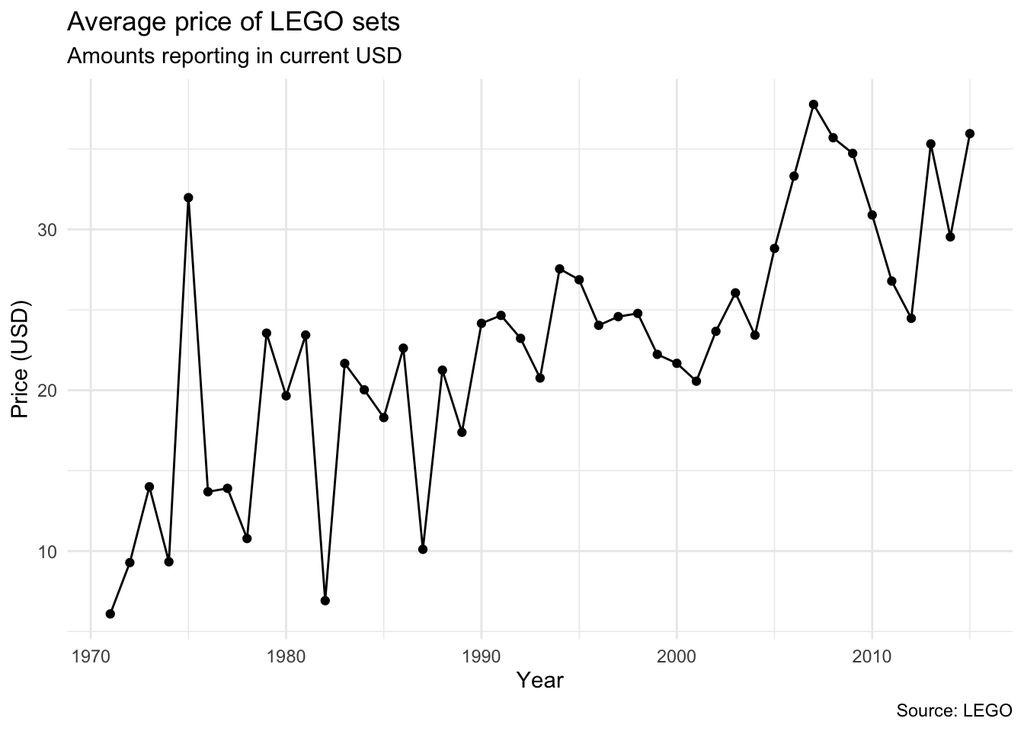

```r
# data wrangling
lego_avg <- legosets %>%
  group_by(Year) %>%
  summarise(avg_usd_msrp = mean(USD_MSRP,na.rm = TRUE))

#plot
ggplot(data=lego_avg,
       mapping=aes(x=Year, y=avg_usd_msrp)
) + geom_point() + geom_line() +
  labs(
    x='Year',
    y = "Price (USD)",
    title = "Average price of LEGO sets",
    subtitle = "Amounts reporting in current USD",
    caption = "Source: LEGO"
  ) + theme_minimal()
```

## Exercise 3

Let’s explore how many unique themes LEGO now offers.

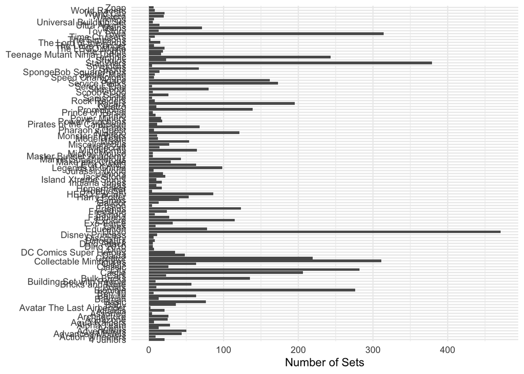

What is bad/ugly about the plot above?

**Solution**

The plot is not that readable. There are too many themes included in the visualization which prevents us from determining which bars correspond to a certain theme. Additionally, the lack of any ordering prevents any ability to determine which themes have the highest and lowest counts.

Now remake the plot BUT with the improvements addressing the issues you noted above.

**Solution**

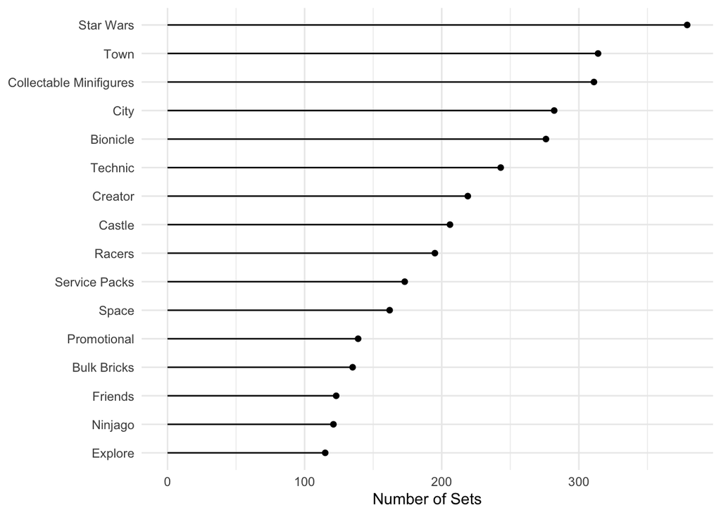

```r
#l label: improved-barplot

# data wrangling
theme_counts <- legosets %>%
  count(Theme, sort=TRUE) %>%
  mutate(Theme = fct_inorder(Theme)%>%fct_rev())

# plot
theme_counts %>%
  filter(Theme != "Duplo")%>%
  filter(n >= 100) %>%
  #slice_max(order_by = n, n=5)%>%
  ggplot(aes(y = Theme, x = n)) +
  geom_point() +
  geom_segment(aes(x=0, y=Theme, xend=n, yend=Theme)) +
  labs(
    x = "Number of Sets",
    y = NULL
  ) +
  theme_minimal()
```

## Exercise 4

Now you try, let’s look at how the number of pieces per set has changed over time. Because Duplo sets are much smaller (since they’re designed for toddlers), we made a special indicator variable for them shown in the code below.

Use an appropriate graph to plot the average number of pieces over time. Have either separate lines or separate plots for the Duplo and Lego categories. Be sure the title, x-axis, and y-axis are properly labeled.

**Solution**

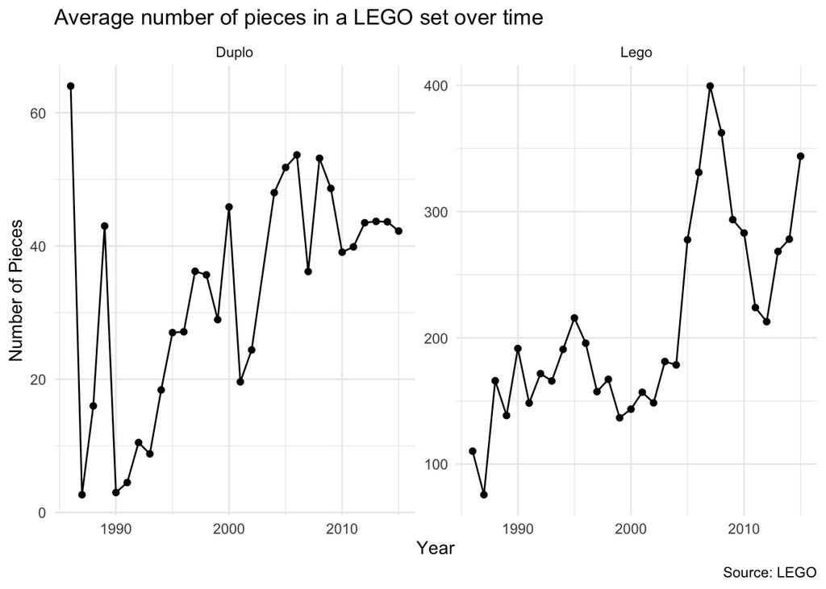

```r
# data wrangling
pieces_per_year <- legosets %>%
  # new indicator variable
  mutate(Duplo = ifelse(Theme == "Duplo", "Duplo", "Lego"))%>%
  group_by(Year, Duplo)%>%
  summarize(avg_num_pieces = mean(Pieces, na.rm=TRUE))%>%
  ungroup()

# facet
pieces_per_year%>%
  filter(Year>1985)%>%
  ggplot(
    mapping=aes(x=Year, y=avg_num_pieces)
) +
  geom_point() +
  geom_line() +
  labs(
    x='Year',
    y = "Number of Pieces",
    title = "Average number of pieces in a LEGO set over time",
    caption = "Source: LEGO"
  ) +
  facet_wrap(~Duplo, scales="free_y") +
  theme_minimal()
```